# 基礎数学

## 機械学習のための応用数学

### 中学以前のレベル

- 図形
- 数と式
- 関数
- 資料の活用

### 高校レベル

- 幾何学
  - 図形の性質
  - 命題の照明
  - 三角比
- 方程式の取り扱い（入門）
  - 1次方程式
  - 2次方程式
  - 高次方程式
  - 連立方程式
- 様々な関数の紹介
  - 1次関数
  - 2次関数
  - 高次関数
  - 指数関数
  - 対数関数
- 資料の活用
  - 確率と統計
    - 場合の数
    - 確率
    - データの分析（入門）

### 大学レベル

- 線形代数学 **※ネットワークの記述に役立つ**
  - ベクトル
  - 行列
  - 1次変換
  - 連立1次方程式と線形計算
  - 行列式
  - 基底と次元
  - 固有値問題
  - 特異値問題
- 微分積分学 **※分析に役立つ**
  - 関数とは何か
  - 線形と非線形
  - 極限
  - 微分
  - 偏微分
  - 積分
- 統計学 **※データの記述と予測に役立つ**
  - 確率変数
  - 確率分布
  - 標本分布
  - 推定
  - 仮説検定
  - 回帰分析
- 情報科学 **※データの定量化に役立つ**

## 方程式と関数

### 方程式とは？

- 未知数が含まれている式
  - 何の役に立つのか？
    - 未知数に対する、ある種の**「説明文」**として役に立つ
- 例：14x + 15 = 71  
  71は既知なので、未知であるxを知ることができる

### 説明文は何の役に立つ？

- 通常「AはBである。」といった形式で表される
  - 一般にAは読者にとって未知のものである
  - 対して、Bは読者にとって既知のもの  
    例）ンジャメナは、アフリカ中央部の国家チャド共和国の首都である
- 「AはAである」
  - 間違いではないが、説明になっていない  
    例）ンジャメナは、ンジャメナである

### 関数とは

- 入力を出力に変換する「装置」のようなもの

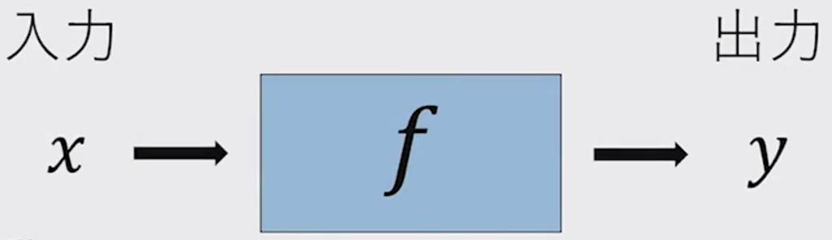

- 数式では、$ y= f(x) $
- $ 14x + 15 = 71 $　というのは、 $ f(x) = 既知の数 $ とも言える  
  つまり、方程式は関数と既知のものの組合せで表すことができる

## 1次方程式

- 未知の部分が1次関数となっている方程式  
  例えば、$ 14x + 15 = 71 $  
  両辺から71を引くと、  
  $ 14x -56 = 0 $  
  両辺に56を足すと、  
  $ 14x = 56 $  
  つまり、  
  $ x = \dfrac{56}{14} = 4 $
- 1次方程式は必ず以下の形式で表せる  
  $ ax + b = 0 $  
  $ ax = -b $  
  $ x = -\dfrac{b}{a} $

### 真数、指数、対数

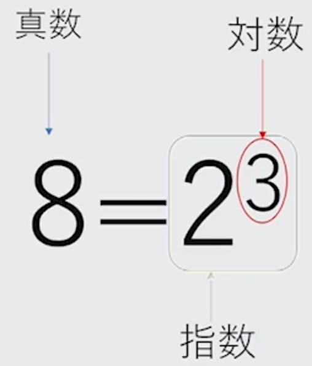

- 真数：普通の数
- 指数：累乗で表される数
- 対数：累乗の方の上の数

### 指数関数

- $ y = a^x $  
  例）$ y = 2^x $
- 計算  
  $ 2^2 \times 2^3 = 2^{2+3} $  
  $ (10^2)^4 = 10^{2\times4} $

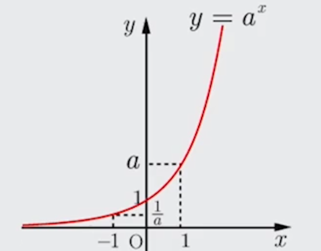

- x=0のときy=1
- x=1のとき、y=a
- x=-1のとき、y=$\dfrac{1}{a} $
- xがどれだけ小さくなってもyはマイナスにならない$ \dfrac{1}{a} \times \dfrac{1}{a} \times \dfrac{1}{a} \times ...$

### 対数関数

- 指数関数の逆関数  
  $ x = a^y $  
  $ y = \log_a x $
- 計算の例  
  $ 8 = 2^3 $  
  $ 3 = \log_2 8 $  
  $ 8 = 2^{\log_2 8} $  
  $ 10 = 2^{\log_2 10} $

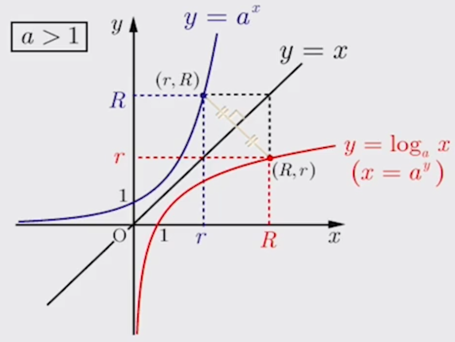

- 底を変換する、重要な関係式  
  $ R = b^{\log_bR} $  
  $ a^{\log_aR} = R $  
  $ b^{\log_ba} = a $  
  $ (b^{\log_ba})^{\log_aR} = b^{\log_bR} $  
  $ \log_ba \times \log_aR = \log_bR $　★⇐ここが大事

  ※ $ (10^2)^4 = 10^{2\times4} $

### 三角比

$ \sin \theta = \dfrac{BC}{AB} = \dfrac{高さ}{斜辺} $  
$ \cos \theta = \dfrac{AC}{AB} = \dfrac{底辺}{斜辺} $  
$ \tan \theta = \dfrac{BC}{AC} = \dfrac{高さ}{底辺} = \dfrac{\sin \theta}{\cos \theta}$

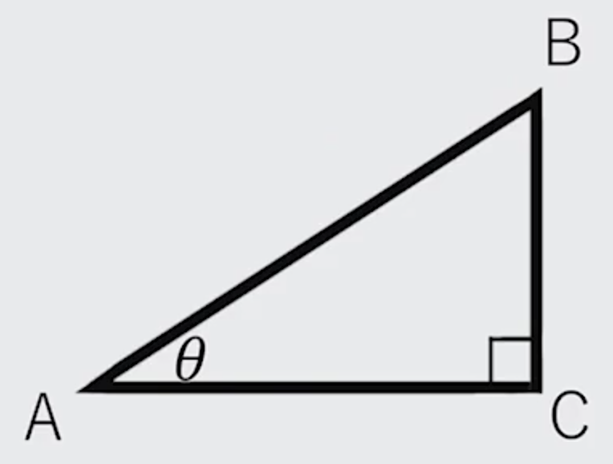

### $ \theta $ が90度以上だったらどうなるか

### 三角関数

$ \sin \theta = \dfrac{y}{r} = \dfrac{高さ}{斜辺} $  
$ \cos \theta = \dfrac{x}{r} = \dfrac{底辺}{斜辺} $  
$ \tan \theta = \dfrac{\sin \theta}{\cos \theta} $

$ \theta $ が$ 90^\circ $ 以上の値をとったとしても成り立つように拡張

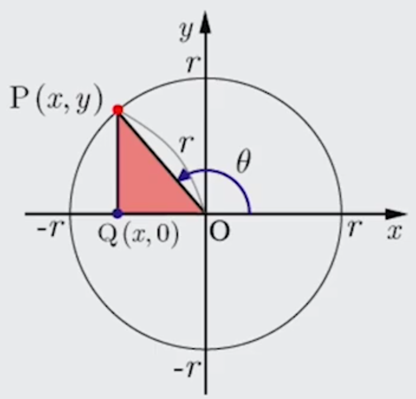

### 連立1次方程式（未知数が複数の方程式）

$ x_1 + 2x_2 = 3 $  
$ x_2 = -\dfrac{1}{2}x_1 + \dfrac{3}{2} $

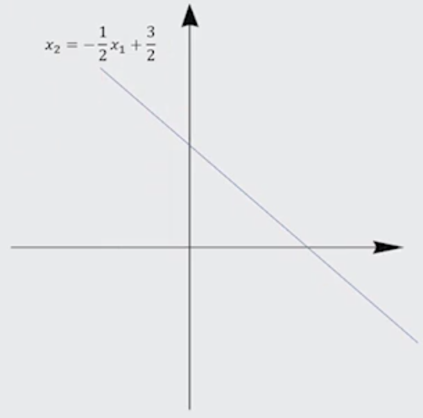

もし、似たような関係式がもう1つあったら、、

$ 2x_1 + 5x_2 = 5 $  
$ x_2 = -\dfrac{2}{5}x_1 + 1 $

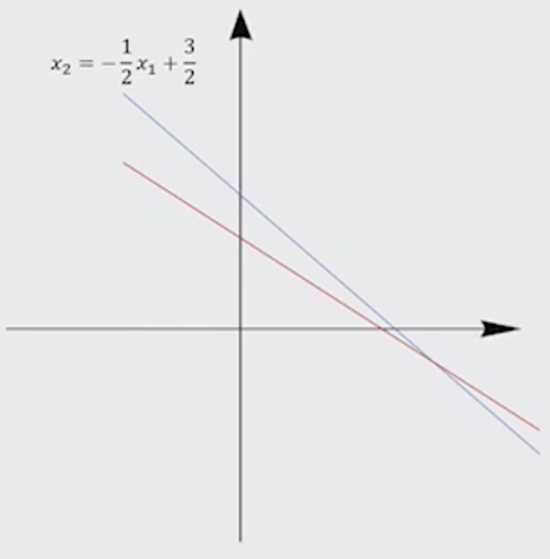

- 未知数が1つある場合、方程式が1つ必要  
  → 未知数の個数と、方程式の数は同じだけ必要

### 行列を用いた表示

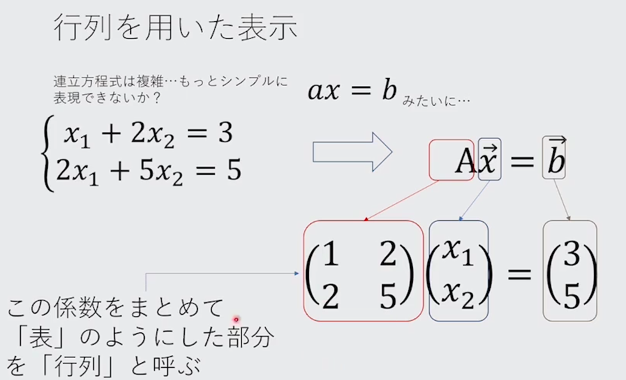